# Part II - Exploring Ford GoBike System Dataset

## Heatmap of User Age and Ride Duration

This heatmap showcases the relationship between user age and ride duration. It provides a visual representation of where ride durations are concentrated for different age groups.

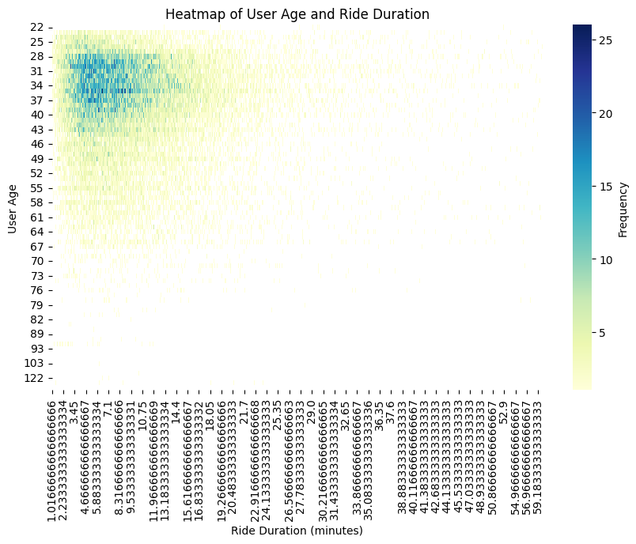

```python
plt.figure(figsize=(10, 6))
heatmap_data = df.groupby(['member_age', 'duration_min']).size().unstack()
sns.heatmap(data=heatmap_data, cmap='YlGnBu', cbar_kws={'label': 'Frequency'})
plt.xlabel('Ride Duration (minutes)')
plt.ylabel('User Age')
plt.title('Heatmap of User Age and Ride Duration')
plt.show()
```

## Pairwise Relationships with PairPlot

This PairPlot provides a matrix of scatter plots for pairs of numerical variables in the dataset. It helps to visualize the relationships between multiple variables at once and identify any potential correlations.

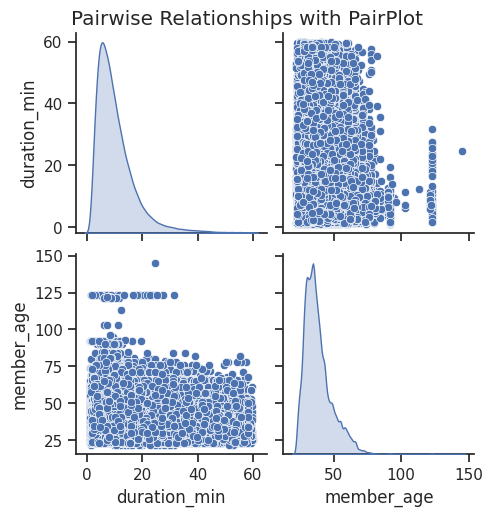

```python
sns.set(style="ticks")
numerical_columns = ['duration_min', 'member_age']
sns.pairplot(df[numerical_columns], diag_kind="kde", markers="o")
plt.suptitle('Pairwise Relationships with PairPlot', y=1.02)
plt.show()
```

### Explanatory Analysis Summary

In this section, we delved deeper into the Bike Sharing dataset to uncover more insights and relationships between variables. Through a series of polished visualizations, we highlighted key findings that shed light on user behavior, trends, and patterns in bike sharing activities. These visualizations provided a more comprehensive understanding of the dataset and its underlying dynamics.